# Scientific processing with SciPy

> SciPy is a collection of mathematical algorithms and convenience functions built on the Numpy extension of Python.

SciPy has a number of modules, so this will be more of a whirlwind tour than an in-depth explanation of each module.

```python
%matplotlib inline
import numpy as np
import matplotlib as mpl
import matplotlib.pyplot as plt
```

## Polynomials

SciPy has a built-in representation of polynomials:

```python
from scipy import poly1d
```

```python
p = poly1d([3,4,5])
print(p)
```

```
   2
3 x + 4 x + 5
```

```python
print(p * p)
```

```
   4      3      2
9 x + 24 x + 46 x + 40 x + 25
```

## "Special" functions in `scipy.special`

SciPy provides several functions useful in mathematical physics in the `special` module. For instance, the Bessel functions are included as `jn` and `jn_zeros`:

```python
from scipy import special
def height(n, k, distance, angle, t):
   kth_zero = special.jn_zeros(n, k)[-1]
   return np.cos(t) * np.cos(n*angle) * special.jn(n, distance*kth_zero)
theta = np.r_[0:2*np.pi:50j]
radius = np.r_[0:1:50j]
x = np.array([r * np.cos(theta) for r in radius])
y = np.array([r * np.sin(theta) for r in radius])
z = np.array([height(1, 1, r, theta, 0.5) for r in radius])
```

```python
from mpl_toolkits.mplot3d import Axes3D
from matplotlib import cm
```

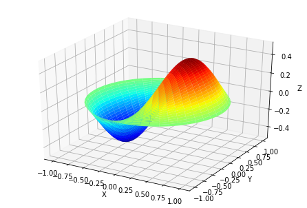

```python
fig = plt.figure()
ax = Axes3D(fig)
ax.plot_surface(x, y, z, rstride=1, cstride=1, cmap=cm.jet)
ax.set_xlabel('X')
ax.set_ylabel('Y')
ax.set_zlabel('Z')
plt.show()
```

## Numerical integration in `scipy.integrate`

```python
from scipy import integrate
```

```python
result, ub_error = integrate.quad(lambda x: special.jv(2.5,x), 0, 4.5)
result
```

```
1.1178179380783253
```

```python
result, ub_error = integrate.quad(lambda x: x, 0, 4)
result
```

```
8.0
```

## Optimization in `scipy.optimize`

SciPy also provides a number of algorithms for optimization:

```python
p = poly1d([1,2,3])
print(p)
```

```
   2
1 x + 2 x + 3
```

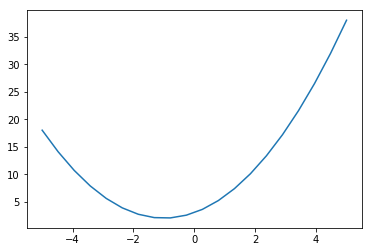

```python
xs = np.r_[-5:5:20j]
ys = p(xs)
plt.plot(xs, ys)
plt.show()
```

```python
from scipy import optimize
```

```python
result = optimize.minimize(p, [-10], method='nelder-mead')
result
```

```
 final_simplex: (array([[-1.        ],
       [-1.00006104]]), array([2., 2.]))
           fun: 2.0
       message: 'Optimization terminated successfully.'
          nfev: 40
           nit: 20
        status: 0
       success: True
             x: array([-1.])
```

We can also use the least-squares algorithm to find a curve to fit an equation so long as we can define a `residuals` and a `peval` function where:

- `residuals(p, y, x)` returns the residuals given a parameter being optimized `p`, as well as `y` and `x`
- `peval(x, p)` returns the `y` value given the parameter `p` and `x`

```python
from numpy import arange, sin, pi, random, array
x = arange(0, 6e-2, 6e-2 / 30)
A, k, theta = 10, 1.0 / 3e-2, pi / 6
y_true = A * sin(2 * pi * k * x + theta)
y_meas = y_true + 2*random.randn(len(x))
```

```python
def residuals(p, y, x):
    A, k, theta = p
    err = y - A * sin(2 * pi * k * x + theta)
    return err

def peval(x, p):
    return p[0] * sin(2 * pi * p[1] * x + p[2])
```

```python
# Initial guess for A, k, theta
p0 = [8, 1 / 2.3e-2, pi / 3]
array(p0)
```

```
array([ 8.        , 43.47826087,  1.04719755])
```

```python
plsq = optimize.leastsq(residuals, p0, args=(y_meas, x))
plsq[0]
```

```
array([-8.73170338, 35.00716167,  3.33504735])
```

```python
A, k, theta
```

```
(10, 33.333333333333336, 0.5235987755982988)
```

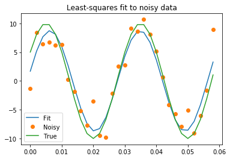

```python
plt.plot(x, peval(x, plsq[0]),x,y_meas,'o',x,y_true)
plt.title('Least-squares fit to noisy data')
plt.legend(['Fit', 'Noisy', 'True'])
plt.show()
```

## Interpolation

```python
from scipy.interpolate import interp1d
```

```python
xs = np.r_[0:10:11j]
ys = np.cos(-xs**2/9.0)
f = interp1d(xs, ys)
f2 = interp1d(xs, ys, kind='cubic')
```

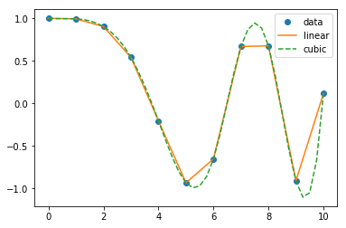

```python
xnew = np.r_[0:10:41j]
plt.plot(xs, ys, 'o', xnew, f(xnew), '-',xnew, f2(xnew), '--')
plt.legend(['data', 'linear', 'cubic'], loc='best')
plt.show()
```

## Fast Fourier Transforms with `fftpack`

> PyFFTW provides a way to replace a number of functions in scipy.fftpack with its own functions, which are usually significantly faster, via pyfftw.interfaces. Because PyFFTW relies on the GPL-licensed FFTW it cannot be included in Scipy. Users for whom the speed of FFT routines is critical should consider installing PyFFTW.

```python
from scipy.fftpack import fft
```

```python
# Number of sample points
N = 600
# sample spacing
T = 1.0 / 800.0
```

```python
xs = np.r_[0.0: N*T: N * 1j]
ys = np.sin(50.0 * 2.0*np.pi*xs) + 0.5*np.sin(80.0 * 2.0*np.pi*xs)
yf = fft(ys)
xf = np.r_[0.0 : 1.0/(2.0*T) : 1j * N/2]
```

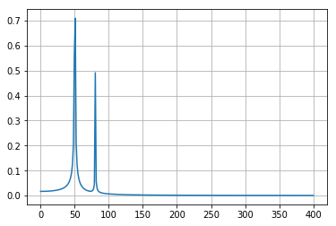

```python
plt.plot(xf, 2.0/N * np.abs(yf[0:N//2]))
plt.grid()
plt.show()
```

## Signal processing with `scipy.signal`

```python
from scipy import misc, signal
image = misc.face(gray=True).astype(np.float32)
derfilt = np.array([1.0, -2, 1.0], dtype=np.float32)
ck = signal.cspline2d(image, 8.0)
deriv = (signal.sepfir2d(ck, derfilt, [1]) +
         signal.sepfir2d(ck, [1], derfilt))
```

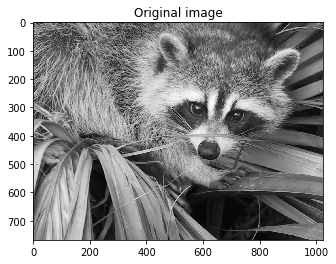

```python
plt.figure()
plt.imshow(image)
plt.gray()
plt.title('Original image')
plt.show()
```

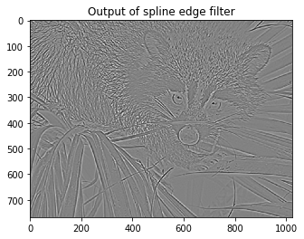

```python
plt.figure()
plt.imshow(deriv)
plt.gray()
plt.title('Output of spline edge filter')
plt.show()
```

## Linear algebra with `scipy.linalg`

While NumPy also has linear algebra support, `scipy.linalg` is a superset of its functionality, and is always compiled with acceleration via BLAS/LAPACK, so use `scipy.linalg` over `numpy.linalg`.

```python
from scipy import linalg
```

```python
A = np.array([[1,2], [3,4]])
A
```

```
array([[1, 2],
       [3, 4]])
```

```python
linalg.inv(A)
```

```
array([[-2. ,  1. ],
       [ 1.5, -0.5]])
```

```python
A.dot(linalg.inv(A))
```

```
array([[1.0000000e+00, 0.0000000e+00],
       [8.8817842e-16, 1.0000000e+00]])
```

```python
b = np.array([[5], [6]])
b
```

```
array([[5],
       [6]])
```

```python
linalg.inv(A).dot(b)
```

```
array([[-4. ],
       [ 4.5]])
```

```python
linalg.solve(A, b)
```

```
array([[-4. ],
       [ 4.5]])
```

```python
A.dot(linalg.solve(A, b))
```

```
array([[5.],
       [6.]])
```

```python
linalg.det(A)
```

```
-2.0
```

## Clustering with `scipy.cluster`

SciPy provides vector quantization (vq) and hierarchical clustering routines as well in the `cluster` package.

```python
N = 50
mean_0 = [5, 8]
size_0 = [1, 1]
mean_1 = [-1, -1]
size_1 = [0.5, 0.5]

xy_0 = np.array([np.random.normal(mean_0, size_0) for i in range(N)])
xy_1 = np.array([np.random.normal(mean_1, size_1) for i in range(N)])
xy = np.r_[xy_0, xy_1]

xs = xy[:,0]
ys = xy[:,1]
```

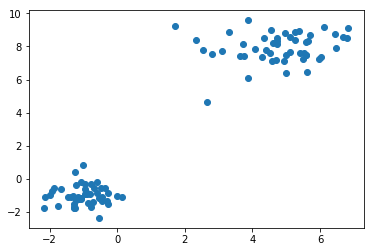

```python
plt.scatter(xs, ys)
plt.show()
```

```python
from scipy import cluster
```

```python
codebook, dist = cluster.vq.kmeans(xy, 2)
codebook
```

```
array([[-0.98923248, -1.00424126],
       [ 4.77694739,  7.9335898 ]])
```

```python
classes, distortions = cluster.vq.vq(xy, codebook)
classes
```

```
array([1, 1, 1, 1, 1, 1, 1, 1, 1, 1, 1, 1, 1, 1, 1, 1, 1, 1, 1, 1, 1, 1,
       1, 1, 1, 1, 1, 1, 1, 1, 1, 1, 1, 1, 1, 1, 1, 1, 1, 1, 1, 1, 1, 1,
       1, 1, 1, 1, 1, 1, 0, 0, 0, 0, 0, 0, 0, 0, 0, 0, 0, 0, 0, 0, 0, 0,
       0, 0, 0, 0, 0, 0, 0, 0, 0, 0, 0, 0, 0, 0, 0, 0, 0, 0, 0, 0, 0, 0,
       0, 0, 0, 0, 0, 0, 0, 0, 0, 0, 0, 0], dtype=int32)
```

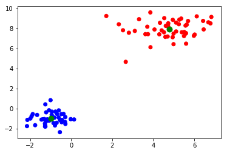

```python
plt.scatter(xs, ys, color=['red' if c else 'blue' for c in classes])
plt.scatter(codebook[:,0], codebook[:, 1], color='green', marker='o', s=80)
plt.show()
```

# File I/O

NumPy and SciPy provide some convenience methods for loading and saving numeric data

```python
A
```

```
array([[1, 2],
       [3, 4]])
```

```python
import scipy.io as sio
```

Matlab files can be loaded and saved

```python
sio.savemat('data/test.mat', {'A': A})
```

```python
sio.loadmat('data/test.mat')
```

```
{'__header__': b'MATLAB 5.0 MAT-file Platform: posix, Created on: Tue Feb 26 18:02:00 2019',
 '__version__': '1.0',
 '__globals__': [],
 'A': array([[1, 2],
        [3, 4]])}
```

If you dont need compatibility with other packages, you can use `np.load`, `np.save` and `np.savez`:

```python
np.save('data/test', A)
```

```python
np.load('data/test.npy')
```

```
array([[1, 2],
       [3, 4]])
```

```python
np.savez('data/test1', A=A, b=np.arange(5))
```

```python
f = np.load('data/test1.npz')
f
```

```
<numpy.lib.npyio.NpzFile at 0x1259a3c88>
```

```python
f.files
```

```
['A', 'b']
```

```python
f['A']
```

```
array([[1, 2],
       [3, 4]])
```

```python
f['b']
```

```
array([0, 1, 2, 3, 4])
```

SciPy can also read and write matrix market files:

```python
sio.mmwrite('data/test_mm', A)
```

```python
sio.mminfo('data/test_mm')
```

```
(2, 2, 4, 'array', 'integer', 'general')
```

```python
sio.mmread('data/test_mm')
```

```
array([[1, 2],
       [3, 4]])
```

Of course, our old friend the CSV file is supported as well:

```python
np.savetxt('data/test.csv', A, delimiter=',')
print(open('data/test.csv').read())
```

```
1.000000000000000000e+00,2.000000000000000000e+00
3.000000000000000000e+00,4.000000000000000000e+00
```

```python
np.loadtxt('data/test.csv', delimiter=',')
```

```
array([[1., 2.],
       [3., 4.]])
```

```python
np.savetxt('data/test.csv', A, fmt='%d', delimiter=',')
np.loadtxt('data/test.csv', dtype=int, delimiter=',')
```

```
array([[1, 2],
       [3, 4]])
```

### Other file types

You can also access the following file types with `scipy.io` (some are read-only):

- IDL (`readsav`) - read-only
- Wav sound files (`read`, `write`)
- Arff files (`loadarf`) - read-only
- NetCDF files (`netcdf_file`) - read-only

# Lab

Open the SciPy Lab